# Interactive data visualization: shiny and plotly

Mahbubul Majumder, PhD  
Nov 2, 2020

### What is shiny ?

- A [web application framework](http://shiny.rstudio.com/) for R
  - can create data driven web application
  - knowledge of HTML, JavaScript and CSS are not necessary
- Can be used to create data product
- D3 plots can be included in shiny application
- Can be easily shared in various ways
  - deploy on RStudio server
  - deploy on your own website

```r
install.packages("shiny")
library(shiny)
```

- Click [here](http://shiny.rstudio.com/gallery/google-charts.html) to view some example

### How shiny works

- You need two `R` source files saved in a folder say `myShinyApp`. Source files should be named
  - `server.R`
  - `ui.R`
- `server.R` contains the `R` codes to
  - generate the plots
  - present tables of results
- `ui.R` contains the `R` codes to
  - design the user interface for facilitating the user interactivity with the plots
  - to add typical widgets such as slider, check box, select box etc.
- Two ways to run your application
  - from command prompt type `runApp("path-to/myShinyApp")`
  - from RStudio, click on `Run App`

### A typical server.R

```r
library(shiny)

# Define server logic required to draw a histogram
shinyServer(function(input, output) {

  # Expression that generates a histogram. The expression is
  # wrapped in a call to renderPlot to indicate that:
  #
  #  1) It is "reactive" and therefore should re-execute automatically
  #     when inputs change
  #  2) Its output type is a plot

  output$distPlot <- renderPlot({
    x    <- faithful[, 2]  # Old Faithful Geyser data
    bins <- seq(min(x), max(x), length.out = input$bins + 1)

    # draw the histogram with the specified number of bins
    hist(x, breaks = bins, col = 'darkgray', border = 'white')
  })
})
```

### A typical ui.R

```r
# Define UI for application that draws a histogram
shinyUI(fluidPage(

  # Application title
  titlePanel("Hello Shiny!"),

  # Sidebar with a slider input for the number of bins
  sidebarLayout(
    sidebarPanel(
      sliderInput("bins",
                  "Number of bins:",
                  min = 1,
                  max = 50,
                  value = 30)
    ),

    # Show a plot of the generated distribution
    mainPanel(
      plotOutput("distPlot")
    )
  )
))
```

### Available widgets

| functions | widget |
| --- | --- |
| actionButton | Action Button |
| checkboxGroupInput | A group of check boxes |
| checkboxInput | A single check box |
| dateInput | A calendar to aid date selection |
| dateRangeInput | A pair of calendars for selecting a date range |
| fileInput | A file upload control wizard |
| helpText | A Help text that can be added to an input form |
| numericInput | A field to enter numbers |
| radioButtons | A set of radio buttons |
| selectInput | A box with choices to select from |
| sliderInput | A slider bar |
| submitButton | A submit button |
| textInput | A field to enter text |

- [Click here to view the shiny widget gallary](http://shiny.rstudio.com/gallery/widget-gallery.html)

### Application layout

- Sidebar Layout `sidebarLayout()`
- Grid Layout
  - Fluid Grid System
  - Fixed Grid
- Tabsets
- Navlists or Navbar
- For more information visit shiny documentation about layout  
  http://shiny.rstudio.com/articles/layout-guide.html
- Example of a navigation bar

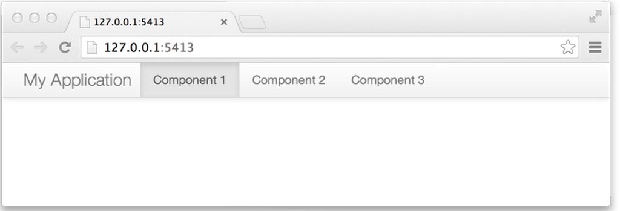

- example of tabsets

[figure not shown]

### Application theme

- The default shiny theme is bootstrap which is usually loaded from downloaded `bootstrap.css`

```r
shinyUI(fluidPage(theme = "bootstrap.css",

  titlePanel("My Application")

  # application UI
))
```

- Some themes can be viewed from
  - http://bootswatch.com/
  - source codes can be viewed and copied depending on which theme you prefer

### Demonstration

### Let us create an application using shiny

- We will create an application to explore US crime data from 1969 to 2005
- The application that we made is already hosted on Github. To launch this application, run the following codes from `R` command prompt

```r
library(shiny)
shiny::runGitHub('usa-crime', 'mamajumder')
```

- Before running this make sure packages `ggplot2`, `dplyr`, `scales` and `ggmap` are already installed.
- The source codes and the data for this application can be downloaded from  
  https://github.com/mamajumder/usa-crime
- The application is deployed on RStudio. To view the application we created visit  
  https://mahbub.shinyapps.io/usa-crime/

### Dashboard for interactive data display

```r
install.packages("shinydashboard")
library(shinydashboard)
```

- For basic dashboard structure

```r
ui <- dashboardPage(
  dashboardHeader(),
  dashboardSidebar(),
  dashboardBody()
)

server <- function(input, output) { }

shinyApp(ui, server)
```

- If you want to put your own title

```r
dashboardHeader(title="My First Dashboard")
```

- Similarly, add side bar and body content. For details, review [dashboard basics](https://rstudio.github.io/shinydashboard/get_started.html)

### Interactive visualization with plotly

[Javascript library plotly](https://plot.ly/)

[ggplot2 with plotly](https://plot.ly/ggplot2/)

we can convert ggplot2 plots into plotly using function `ggplotly()`

### plotly example

```r
library(plotly)

mtcars$am[which(mtcars$am == 0)] <- 'Automatic'
mtcars$am[which(mtcars$am == 1)] <- 'Manual'
mtcars$am <- as.factor(mtcars$am)

p <- plot_ly(mtcars, x = ~wt, y = ~hp, z = ~qsec, color = ~am, colors = c('#BF382A', '#0C4B8E')) %>%
  add_markers() %>%
  layout(scene = list(xaxis = list(title = 'Weight'),
                     yaxis = list(title = 'Gross horsepower'),
                     zaxis = list(title = '1/4 mile time')))

p
```

[output not shown]

### Reading assignment and references

- To view the shiny application we created to explore US crime data visit  
  https://mahbub.shinyapps.io/usa-crime/
- Shiny web site  
  http://shiny.rstudio.com/
- Shiny cheat sheet, a very useful reference guide. Check for updates.  
  http://shiny.rstudio.com/articles/cheatsheet.html
- Overview of `R` package `ggvis`  
  http://ggvis.rstudio.com/